# Political Replication Project

Author

Luna Bellitto

# 1. Introduction

The scope of this paper is to replicate and expand the statistical analysis presented in ‘Religious Protection from Populist Violence’ by Brooke et al. (2023). In particular, it focuses on replicating Model 4 from the original study and conducting additional analyses to explore potential improvements to the model.

Model 4 of the original paper predicts the number of killings occurred in the Philippines during the war on drugs. The model employs religious, economical, social, and political features gathered from different sources.

The first part of this project is dedicated to the replication of the original model, followed by efforts to develop new models aimed at improving predictive accuracy. In the analysis, a few models will be evaluated, and the best performing one will be selected to to generate scenario analyses focusing on a key independent variable of interest.

## 1.1 Original Analysis

The original study aims to understand the impact of international institutions in protecting from populist violence. In particular, the authors focus on religious institutions, believing that the latter are able to raise awareness on violence, provide protections for the citizens, and mobilize against the institutionalised use of force. The example analyzed in the original study focuses on the role of the Roman Catholic Church in reducing violence in the Philippines during the war on drugs. For this purpose, Brooke et al. (2023) develop models to predict the number of drug-related killings per neighborhood (barangay) in the National Capital Region (NCR). Using causal inference techniques, the study assesses whether the presence of Catholic parishes is associated with a decrease in killings.

The data-set includes data from the census, electoral returns, and transgovernmental organizations. The dependent variable accounts for the number of killings in each barangay, making it count data. Given that the analysis is conducted at the barangay level, the proximity of the different areas of interest raise concerns regarding the observational independence of the predictors. The large number of zeros in the data-set (Figure 1) suggests the presence of overdispersion, which makes a negative binomial the regression model of choice for the original study, and the population variable the exposure factor. For what concerns missing data, the authors dropped them leaving a data-set of 1,696 observations.

```r
library(haven)
library(MASS)
library(knitr)
library(texreg)
library(sandwich)
library(lmtest)
library(caret)
library(cvTools)
library(Metrics)
```

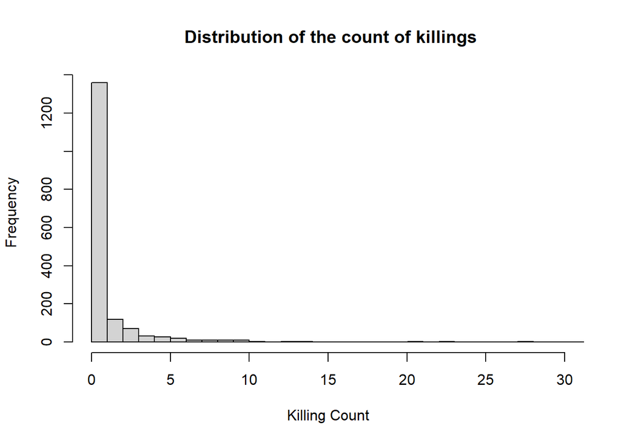

```r
#Dependent variable distribution
dat <- read_dta('bbdm_drug_war.dta')
dat <- na.omit(dat)
hist(dat$killing_count,
     main = " Distribution of the count of killings",
     xlab = "Killing Count",
     xlim = c(0,30),
     breaks = 100)
```

```r
dat$level_edu <- 100 - dat$pct_hs_grad
```

Figure 1. Representation of the Killing Count distribution. From the plot, it is possible to see the presence of overdispersion.

# 2 Predictive Models

## 2.1 Replication Model

In the original study, the authors analyse different models to predict the number of killings per barangay, consistently using a negative binomial regression for the inference due to overdispersion in the data; they also pick the logarithm of population as exposure term, accounting for different population sizes. Following this reasoning, the study includes four models that differ from each other for the selection of independent variables. The full model, which is the one replicated in this project, accounts for the presence of Catholic Churches in the barangay, the demographic of the victims, the political sentiment, the presence of police stations, and the presence of Methodist Churches.

More precisely, the demographic variables account for the percentage of the population with high school diplomas and the percentage of the presence of men between 15-24 years old since these two factors are assumed by the authors to belong to the population most at risk for “petty criminality” (Brooke et al., 2023). The political sentiment, instead, mainly refers to the support for Rodrigo Duerte, who strongly implemented the war on drugs in the Philippines. The presence of Methodist Churches performs a placebo test to verify that Catholic Churches themselves are reducing the number of victims thanks to their structure. Consequently, a lack of the difference between the two might signify a not valid assumption.

```r
#Dependent variable
#the dependent variable is the total count of killings
dat$killing_count = dat$police_killing_count + dat$vigilante_killing_count
# sum(dat$killing_count)
# names(dat)


model_repli <- glm.nb(killing_count ~ rc_dummy + pct_catholic + pct_hs_grad +
                 pct_at_risk_pop + duterte_share + enp_sen + police_dummy +
                 pct_nccp + methodist_dummy + offset(log(population)), #log population automatically applied on stata
                 data = dat)

coeftest(model_repli, vcov = vcovCL(model_repli, cluster = ~ municipality))
```

```
z test of coefficients:

                   Estimate  Std. Error z value  Pr(>|z|)
(Intercept)     -7.60745447  2.17834417 -3.4923 0.0004789 ***
rc_dummy        -0.34317941  0.09681460 -3.5447 0.0003930 ***
pct_catholic    -0.00833690  0.00673596 -1.2377 0.2158384
pct_hs_grad     -0.05145859  0.00683048 -7.5337 4.933e-14 ***
pct_at_risk_pop  0.06118123  0.01925350  3.1777 0.0014846 **
duterte_share   -0.00044572  0.01350096 -0.0330 0.9736637
enp_sen          0.12649021  0.07143456  1.7707 0.0766082 .
police_dummy    -0.08336618  0.11173760 -0.7461 0.4556137
pct_nccp        -0.20289465  0.08038715 -2.5240 0.0116038 *
methodist_dummy  0.21199569  0.13740664  1.5428 0.1228709
---
Signif. codes:  0 '***' 0.001 '**' 0.01 '*' 0.05 '.' 0.1 ' ' 1
```

```r
#taking the exponents of the coefficients because Stata uses exponentiated coefficients while R reports log coefficients
model_repli_exp <- exp(coef(model_repli))
```

```r
#making the table
texreg(
  list(model_repli),
  override.coef = model_repli_exp,
  custom.model.names = "Replicated Model",
  include.aic = TRUE,
  include.bic = TRUE,
  include.loglik = TRUE,
  stars = c(0.1, 0.05, 0.01),
  single.row = FALSE,
  scalebox = 0.6,
  use.packages = FALSE,
  float.pos = 'H',
  file = "model_output.tex"
)

# In RMarkdown, insert this inside a LaTeX block
knitr::asis_output("\\input{model_output.tex}")
```

## 2.2 Additional Models

During the analysis of the original paper, different predictors were analysed. The focus was mainly on political, economic, religious, and social factors. The following two models will test the interaction of economic variables and their influence on the predictions of killing counts.

### 2.4 Economic Model

```r
#Fitting a model that considers if the interaction between not getting a diploma and unemployment (economic uncertainty) affects the number of killings

model_polecon <- glm.nb(killing_count ~ rc_dummy + pct_catholic +
                            level_edu * pct_informal_unemp +
                            pct_at_risk_pop + duterte_share + enp_sen +
                            police_dummy + pct_nccp + methodist_dummy +
                            offset(log(population)), data = dat)

model_polecon_summary <- summary(model_polecon)

#taking the exponents of the coefficients because Stata uses exponentiated coefficients while R reports log coefficients
model_polecon_summary$coefficients[, 1] <- exp(model_polecon_summary$coefficients[, 1])
print(model_polecon_summary)
```

```
Call:
glm.nb(formula = killing_count ~ rc_dummy + pct_catholic + level_edu *
    pct_informal_unemp + pct_at_risk_pop + duterte_share + enp_sen +
    police_dummy + pct_nccp + methodist_dummy + offset(log(population)),
    data = dat, init.theta = 0.7066274286, link = log)

Coefficients:
                              Estimate Std. Error z value Pr(>|z|)
(Intercept)                  2.543e-06  1.880e+00  -6.851 7.33e-12 ***
rc_dummy                     7.297e-01  1.150e-01  -2.741  0.00613 **
pct_catholic                 9.921e-01  6.852e-03  -1.161  0.24573
level_edu                    1.142e+00  4.031e-02   3.289  0.00101 **
pct_informal_unemp           1.036e+00  3.308e-02   1.076  0.28214
pct_at_risk_pop              1.051e+00  3.382e-02   1.468  0.14203
duterte_share                1.000e+00  7.702e-03   0.044  0.96474
enp_sen                      1.078e+00  4.332e-02   1.724  0.08466 .
police_dummy                 9.148e-01  1.116e-01  -0.798  0.42481
pct_nccp                     8.312e-01  9.894e-02  -1.869  0.06166 .
methodist_dummy              1.256e+00  2.705e-01   0.843  0.39939
level_edu:pct_informal_unemp 9.979e-01  1.048e-03  -1.969  0.04897 *
---
Signif. codes:  0 '***' 0.001 '**' 0.01 '*' 0.05 '.' 0.1 ' ' 1

(Dispersion parameter for Negative Binomial(0.7066) family taken to be 1)

    Null deviance: 1456.8  on 1695  degrees of freedom
Residual deviance: 1356.2  on 1684  degrees of freedom
AIC: 3943.1

Number of Fisher Scoring iterations: 1

              Theta:  0.7066
          Std. Err.:  0.0608

 2 x log-likelihood:  -3917.1310
```

```r
#Fitting a model that takes into account the interaction between unemployment and high school diploma, but that does not focus a lot on the political environment

model_econ <- glm.nb(killing_count ~ rc_dummy + pct_catholic +
                            level_edu * pct_informal_unemp +
                            pct_at_risk_pop + police_dummy + pct_nccp
                            + methodist_dummy + offset(log(population)), data = dat)

model_econ_summary <- summary(model_econ)

#taking the exponents of the coefficients because Stata uses exponentiated coefficients while R reports log coefficients
model_econ_summary$coefficients[, 1] <- exp(model_econ_summary$coefficients[, 1])
print(model_econ_summary)
```

```
Call:
glm.nb(formula = killing_count ~ rc_dummy + pct_catholic + level_edu *
    pct_informal_unemp + pct_at_risk_pop + police_dummy + pct_nccp +
    methodist_dummy + offset(log(population)), data = dat, init.theta = 0.7032150555,
    link = log)

Coefficients:
                              Estimate Std. Error z value Pr(>|z|)
(Intercept)                  2.188e-05  1.293e+00  -8.298  < 2e-16 ***
rc_dummy                     7.410e-01  1.148e-01  -2.612 0.008994 **
pct_catholic                 9.881e-01  5.882e-03  -2.030 0.042346 *
level_edu                    1.148e+00  4.008e-02   3.449 0.000562 ***
pct_informal_unemp           1.038e+00  3.298e-02   1.122 0.261809
pct_at_risk_pop              1.051e+00  3.391e-02   1.467 0.142452
police_dummy                 9.360e-01  1.098e-01  -0.602 0.547098
pct_nccp                     8.289e-01  9.848e-02  -1.905 0.056717 .
methodist_dummy              1.238e+00  2.715e-01   0.786 0.431770
level_edu:pct_informal_unemp 9.977e-01  1.038e-03  -2.174 0.029713 *
---
Signif. codes:  0 '***' 0.001 '**' 0.01 '*' 0.05 '.' 0.1 ' ' 1

(Dispersion parameter for Negative Binomial(0.7032) family taken to be 1)

    Null deviance: 1453.9  on 1695  degrees of freedom
Residual deviance: 1355.7  on 1686  degrees of freedom
AIC: 3941.3

Number of Fisher Scoring iterations: 1

              Theta:  0.7032
          Std. Err.:  0.0604

 2 x log-likelihood:  -3919.2860
```

```r
model_repli_exp <- exp(coef(model_repli))
model_polecon_exp <- exp(coef(model_polecon))
model_econ_exp <- exp(coef(model_econ))

texreg(
  list(model_repli, model_polecon, model_econ),
  override.coef = list(model_repli_exp, model_polecon_exp, model_econ_exp),
  custom.model.names = c("Replicated Model", "Economic and Political Model", "Economic Model"),
  column.spacing = 1,
  outer.rule = "-",
  inner.rule = "-",
  include.aic = TRUE, include.bic = TRUE, include.loglik = TRUE,
  stars = c(0.1, 0.05, 0.01),
  scalebox = 0.6,
  use.packages = FALSE,
  float.pos = 'H',
  transform = exp,
  file = "model_output_2.tex"
)

# Insert the LaTeX table into RMarkdown
knitr::asis_output("\\input{model_output_2.tex}")
```

# 3 Model Evaluation

All models in this analysis are negative binomial regressions, but each employes variables to focus on different social aspects. The first model is a replication of the original study and mainly focuses on political, religious, demographic and economic predictors. The “Political and Economic Model” changes the demographic variables by substituting the percentage of population with a diploma with the population that does not have a higher degree and is not legally employed. The “Economic Model” highlights economic factors rather than political ones. Consequently, a successful prediction of killings from the latter model signify economic conditions have an independent effect on the war on drugs even if not accounting for political factors. The significance of this predictor confirms this assumption. In order to compare the performance of the model, in-sample and out-of-sample evaluation is performed.

## 3.1 In Sample Evaluation

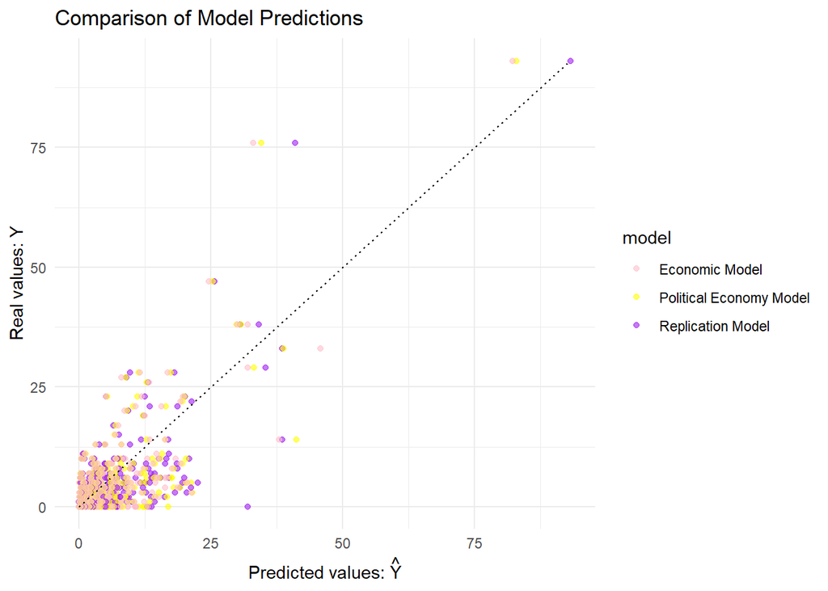

```r
library(ggplot2)
library(dplyr)
library(tidyr)
library(MASS)  # For glm.nb

# Add predictions from all models
dat <- dat %>%
  mutate(pred_repli = predict(model_repli, newdata = ., type = "response"),
         pred_polecon = predict(model_polecon, newdata = ., type = "response"),
         pred_econ = predict(model_econ, newdata = ., type = "response"))

# Reshape data to long format for easier ggplot handling
dat_long <- dat %>%
  pivot_longer(cols = starts_with("pred_"), names_to = "model", values_to = "predicted")

# Rename model labels for readability
dat_long$model <- recode(dat_long$model,
                         "pred_repli" = "Replication Model",
                         "pred_polecon" = "Political Economy Model",
                         "pred_econ" = "Economic Model")

min_val <- min(c(dat_long$predicted, dat$killing_count), na.rm = TRUE)
max_val <- max(c(dat_long$predicted, dat$killing_count), na.rm = TRUE)


# Plot
ggplot(dat_long, aes(x = predicted, y = killing_count, color = model)) +
  geom_point(alpha = 0.6) +  # Scatter plot for all models
  geom_line(data = data.frame(x = c(min_val, max_val), y = c(min_val, max_val)),
            aes(x = x, y = y), linetype = "dotted", color = "black") +
  labs(x = expression("Predicted values: " * hat(Y)),
       y = expression("Real values: " * Y),
       title = "Comparison of Model Predictions") +
  theme_minimal() +
  scale_color_manual(values = c("pink", "yellow", "purple"))
```

Figure 2. The diagonal represents ideal perfect predictions while the different dots are the real values plotted against the predicted ones. The figure allows to understand how each prediction of the model is far from the real value.

## 3.2 Out-of-Sample Evaluation

Model evaluation involves comparing the performance of each model on testing data. For this purpose, a 10-fold cross-validation is used to evaluate the models on an out-of-sample basis. The performance is evaluated by comparing the Mean Squared Error and the R-squared, presented in Table 3.

```r
# Set number of folds
k <- 10
set.seed(123)

# Create k folds
folds <- cvFolds(nrow(dat), K = k)

# Function to perform k-fold CV and compute metrics
cv_nb_model <- function(formula, data, folds) {
  mse_values <- numeric(k)
  rmse_values <- numeric(k)
  mae_values <- numeric(k)
  r2_values <- numeric(k)
  pearson_corr <- numeric(k)
  mape_values <- numeric(k)

  for (i in 1:k) {
    # Split data into train and test sets
    train_idx <- which(folds$which != i)
    test_idx <- which(folds$which == i)

    train_data <- data[train_idx, ]
    test_data <- data[test_idx, ]

    # Fit negative binomial model
    model <- glm.nb(formula, data = train_data)

    # Predict on test set
    preds <- predict(model, newdata = test_data, type = "response")

    # Compute Metrics
    mse_values[i] <- mean((test_data$killing_count - preds)^2)  # MSE
    rmse_values[i] <- sqrt(mse_values[i])                      # RMSE
    mae_values[i] <- mean(abs(test_data$killing_count - preds)) # MAE
    r2_values[i] <- cor(test_data$killing_count, preds)^2      # R-squared
    pearson_corr[i] <- cor(test_data$killing_count, preds)     # Pearson Correlation
    mape_values[i] <- mean(abs((test_data$killing_count - preds) / test_data$killing_count)) * 100  # MAPE
  }

  # Return aggregated metrics
  return(c(
    mean(mse_values), mean(rmse_values), mean(mae_values),
    mean(r2_values), mean(pearson_corr), mean(mape_values)
  ))
}

# Define formulas for models
formula_replica <- killing_count ~ rc_dummy + pct_catholic + pct_hs_grad +
                pct_at_risk_pop + duterte_share + enp_sen + police_dummy +
                pct_nccp + methodist_dummy + offset(log(population))

formula_polecon <- killing_count ~ rc_dummy + pct_catholic +
                   level_edu * pct_informal_unemp + pct_at_risk_pop +
                   duterte_share + enp_sen + police_dummy + pct_nccp +
                   methodist_dummy + offset(log(population))

formula_econ <- killing_count ~ rc_dummy + pct_catholic +
                level_edu * pct_informal_unemp + pct_at_risk_pop +
                police_dummy + pct_nccp + methodist_dummy + offset(log(population))

# Run cross-validation for each model
results_replica <- cv_nb_model(formula_replica, dat, folds)
results_polecon <- cv_nb_model(formula_polecon, dat, folds)
results_econ <- cv_nb_model(formula_econ, dat, folds)

# Combine results into a dataframe
cv_results <- data.frame(
  Model = c("Replication Model", "Political Economic Model", "Economic Model"),
  MSE = c(results_replica[1], results_polecon[1], results_econ[1]),
  RMSE = c(results_replica[2], results_polecon[2], results_econ[2]),
  MAE = c(results_replica[3], results_polecon[3], results_econ[3]),
  R_squared = c(results_replica[4], results_polecon[4], results_econ[4]),
  Pearson_Correlation = c(results_replica[5], results_polecon[5], results_econ[5])
)

# Print results

kable(cv_results, digits = 3, caption = "Cross-Validation Results")
```

Cross-Validation Results

| Model | MSE | RMSE | MAE | R_squared | Pearson_Correlation |
| --- | --- | --- | --- | --- | --- |
| Replication Model | 8.998 | 2.929 | 1.312 | 0.538 | 0.719 |
| Political Economic Model | 8.778 | 2.885 | 1.302 | 0.531 | 0.713 |
| Economic Model | 8.541 | 2.848 | 1.292 | 0.534 | 0.716 |

Table 3. Out-of-sample results from a 10-fold cross-validation evaluating the three models under analysis. The Economic Model shows slightly lower residuals (MSE, RMSE), indicating better predictive accuracy. However, the Replication Model demonstrates the highest R squared, suggesting it better explains the most variance in the data.

Table 3 displays the results of the out-of-sample evaluation. The differences in residuals across models are minimal. By checking the Mean Squared Error, the Replication Model exhibits the largest residual, followed by the Political Economic Model, and the Economic Model having the lowest. Thus, the latter achieves the smallest residuals, suggesting slightly better predictive accuracy. However, these differences are so minor that they are not significant in determining the best-performing model (Figure 3).

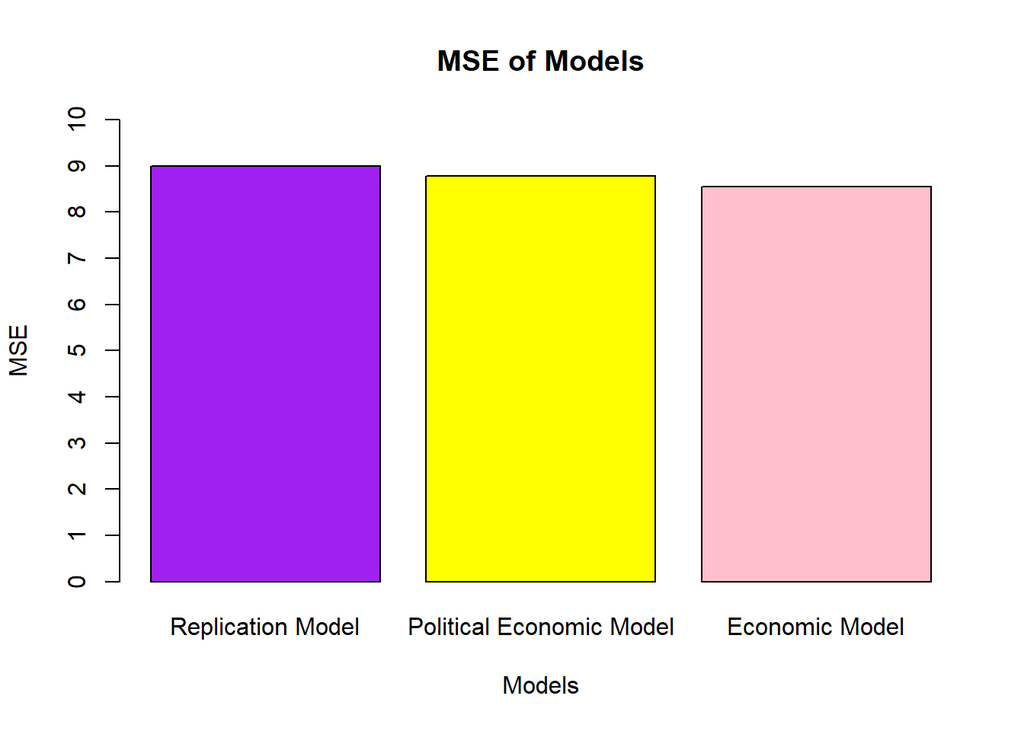

```r
#plotting the MSE
colors <- c("purple", "yellow", "pink")

barplot(cv_results$MSE, names.arg = cv_results$Model, xlab = "Models",
        col = colors,
        ylab = "MSE", main = "MSE of Models",
        ylim = c(0, 10),
        yaxt = "n")

axis(2, at = seq(0, 10, by = 1))
```

Figure 3. Representation of the Mean Squared Error for each model based on 10-fold cross-validation. While the Economic Model has the lowest MSE, the differences are minimal and negligible.

Another key parameter for assessing model performance is the R squared. Having the role of indicating the proportion of variance in the dependent variable explained by the model, the highest R squared suggests better explanatory power. As shown in Table 3, the Replication Model is the most successful in this aim, followed by the Economic Model, and the Political and Economic Model in the end. However, the differences among the three models are minimal, meaning R-squared alone cannot be sufficient to determine the best performing model. Figure 4 provides a visual comparison of this parameter.

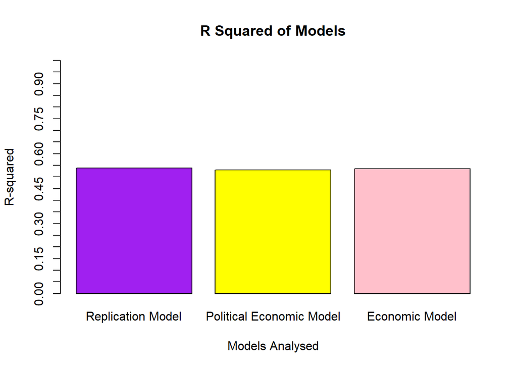

```r
#plotting the R squared

barplot(cv_results$R_squared, names.arg = cv_results$Model, xlab = "Models Analysed",
        col = colors,
        ylab = "R-squared", main = "R Squared of Models",
        ylim = c(0, 1),
        yaxt = "n")

axis(2, at = seq(0, 1, by = 0.05))
```

Figure 4. Visualization of R-squared from a 10-fold cross-validation. The Replication Model performs best, having the largest R-square, but the differences among the models remain minimal.